# TimeSeriesOnlyPCV10

2025-07-14

For our time series analysis, we modeled carriage cases from PCV10 serotypes over time. Due to our limited data, we were unable to look at disease cases as well. From our EDA, we saw different trends in carriage and disease cases over time, and thus did not want to combine them.

We start by loading in packages:

```r
library(ggtext)
library(MASS)
library(tidyverse)
```

```r
library(ggplot2)

nepal_gps = read.csv("nepal_gps.csv")
nepal_nonGPS = read.csv("nepal.csv")
```

We decided to combine carriage cases from our two data sources to have more data to work with. We used non-PCV10 carriage cases from both sources as an offset (more on that later), so inconsistencies in data reporting were accounted for in the model. We also only had aggregate year data (no seasonality). Both of these were challenges when constructing this model, but we worked within the limits of our data. We also had to filter out 2014 to get the model to fit correctly: otherwise the error bars stretched below 0 cases (obviously impossible). We hypothesize that there was better surveillance in Nepal in 2014 as that was the year before vaccine intervention.

First we combined the datasets:

```r
### Starting with Non-GPS dataset
# selecting only PCV10 serotypes
pcv10Serotypes2 <- c('PCV10serotypes')
nonGpsShortened <- nepal_nonGPS[nepal_nonGPS$Serotype %in% pcv10Serotypes2, ]
# selecting all the non PCV10 serotypes to be used in the offset from the non-GPS dataset
NONpcv10Serotypes <- c('3', '6A', '19A', '22F', '33F', '8', '10A', '11A', '12F', '15B', 'Other')
NONPCVforGPS <- nepal_nonGPS[nepal_nonGPS$Serotype %in% NONpcv10Serotypes, ]
# pivoting the non-GPS PCV10 dataset
pcv10NonGpsCarriage <- nonGpsShortened %>%
  # Selecting year columns
  dplyr::select(X2014n, X2015n, X2017n, X2018n, X2019n, X2021n) %>%
  # Formatting data frame
  pivot_longer(cols = everything(),
               names_to = "Year",
               values_to = "Count") %>%
  # Removing X and n from the year counts
  mutate(Year = gsub("X|n", "", Year)) %>%
  group_by(Year) %>%
  slice_tail()
# Pivoting the non-GPS non-PCV10 dataset
NonPCVForOffset <- NONPCVforGPS %>%
  # Selecting year columns
  dplyr::select(X2014n, X2015n, X2017n, X2018n, X2019n, X2021n) %>%
  # Formatting data frame
  pivot_longer(cols = everything(),
               names_to = "Year",
               values_to = "Count") %>%
  # Removing X and n from the year counts
  mutate(Year = gsub("X|n", "", Year)) %>%
  group_by(Year) %>%
  slice_tail()

### GPS Dataset
# defining the serotypes that are in the pcv10 vaccine
pcv10_serotypes <- c('1', '4', '5', '6B', '7F', '9V', '14', '18C', '19F', '23F')

# selecting three variables of interest
GpsShortened <- nepal_gps[, c("Year", "Clinical_manifestation", "In_silico_serotype")]

# adding a new column: PCV10 or not
GpsShortened$PCV10_group <- ifelse(GpsShortened$In_silico_serotype %in% pcv10_serotypes,"PCV10", "Non-PCV10")
# selecting only PCV10
pcv10GpsCarriage <- GpsShortened[GpsShortened$PCV10_group == "PCV10", ]
# selecting only non-PCV10
NONpcv10GpsCarriage <- GpsShortened[GpsShortened$PCV10_group == "Non-PCV10", ]

# Selecting only carriage cases and calculating the count of cases for each year for the PCV10 and non-PCV10 cases
pcv10GpsCarriage2 <- pcv10GpsCarriage %>%
  dplyr::filter(Clinical_manifestation == "CARRIAGE") %>%
  group_by(Year) %>%
  dplyr::summarize(IPDCount = n())

NONpcv10GpsCarriage2 <- NONpcv10GpsCarriage %>%
  dplyr::filter(Clinical_manifestation == "CARRIAGE") %>%
  group_by(Year) %>%
  dplyr::summarize(IPDCountNONPCV10 = n())

### Merging the datasets
# merging for the pcv10 cases
mergedPcv10CarriageDf <- merge(pcv10NonGpsCarriage, pcv10GpsCarriage2, by = "Year", all = TRUE)
# merging the non-PCV10 cases
mergedNONpcv10CarriageDf <- merge(NonPCVForOffset, NONpcv10GpsCarriage2, by = "Year", all = TRUE)

# adding the total counts for carriage to each
mergedPcv10CarriageDf$CCount <- rowSums(mergedPcv10CarriageDf[, c("Count", "IPDCount")], na.rm = TRUE)
mergedNONpcv10CarriageDf$CCountNONPCV10 <- rowSums(mergedNONpcv10CarriageDf[, c("Count", "IPDCountNONPCV10")], na.rm = TRUE)

# final merging
mergedwithOffset <- merge(mergedPcv10CarriageDf, mergedNONpcv10CarriageDf, by = "Year", all = TRUE)

# selecting only the columns we need: year, PCV10 counts, non-PCV10 counts
analysisDf <- mergedwithOffset %>%
  dplyr::select(Year, CCount, CCountNONPCV10) %>%
  filter(Year != 2014)
```

Now that our data has been cleaned, we move onto modeling. We used an interrupted time series model with connected segments (spline model) and a negative binomial fit, using non-PCV10 cases as an offset. While using other pneumococcal cases as an offset is not ideal, it was the best we could do based on the inconsistent data reporting over time. It helped account for this issue and gave us a model that fit our data better than any other offset that we tried.

We first prepare the data to be fit:

```r
# creating an index variable
time_series_df <- tibble::rownames_to_column(analysisDf, var = "index") %>%
 mutate(index = as.numeric(index))

# assigning the introduction date to be January 1st, 2015: not accurate, but since we only have aggregate year data, assigning the intro date to be anytime in 2015 works for our purposes
vax.intro.date <- as.Date('2015-01-01')
vax.intro.year <- format(vax.intro.date, "%Y")

# assigning the evaluation date to be 2017 because there is no 2016 data
vax.eval.date <- as.Date('2017-01-01')
vax.eval.year <- format(vax.eval.date, "%Y")

# identifying the index of the intro and eval year
intro.index <- which(time_series_df$Year == year(vax.intro.date))
eval.index <- which(time_series_df$Year == year(vax.eval.date))

# converting indices to numeric
intro.index <- as.numeric(intro.index)
eval.index <- as.numeric(eval.index)

# creating two splines, spl1 being time since vaccine intro (0 before intro), and spl2 being time since vaccine eval point (0 before eval)
time_series_df <- time_series_df %>%
  mutate(spl1 = ifelse(index - intro.index + 1 < 0, 0, index - intro.index + 1),
         spl2 = ifelse(index - eval.index + 1 < 0, 0, index  - eval.index + 1))

# viewing selected columns
time_series_df[c("Year", "index", "spl1", "spl2")]
```

| Year | index | spl1 | spl2 |
| --- | --- | --- | --- |
| 2009 | 1 | 0 | 0 |
| 2012 | 2 | 0 | 0 |
| 2015 | 3 | 1 | 0 |
| 2017 | 4 | 2 | 1 |
| 2018 | 5 | 3 | 2 |
| 2019 | 6 | 4 | 3 |
| 2021 | 7 | 5 | 4 |

```r
# creating the log offset by selecting all non-PCV10 cases
time_series_df$log.offset <- log(time_series_df$CCountNONPCV10)
```

We then fit the data using a negative binomial regression:

```r
# fit the model
neg_bin_model <- glm.nb(CCount ~ index  + offset(log.offset) + spl1 + spl2, data = time_series_df)
summary(neg_bin_model)
```

```
##
## Call:
## glm.nb(formula = CCount ~ index + offset(log.offset) + spl1 +
##     spl2, data = time_series_df, init.theta = 245.4948542, link = log)
##
## Coefficients:
##             Estimate Std. Error z value Pr(>|z|)
## (Intercept)  -1.6172     0.5107  -3.167  0.00154 **
## index         0.2429     0.3252   0.747  0.45510
## spl1          0.6327     0.5256   1.204  0.22869
## spl2         -1.4222     0.2690  -5.287 1.24e-07 ***
## ---
## Signif. codes:  0 '***' 0.001 '**' 0.01 '*' 0.05 '.' 0.1 ' ' 1
##
## (Dispersion parameter for Negative Binomial(245.4949) family taken to be 1)
##
##     Null deviance: 132.678  on 6  degrees of freedom
## Residual deviance:   5.237  on 3  degrees of freedom
## AIC: 57.3
##
## Number of Fisher Scoring iterations: 1
##
##
##               Theta:  245
##           Std. Err.:  499
##
##  2 x log-likelihood:  -47.3
```

We then create our factual model (modeling what actually happened), and a counterfactual model (what would have happened if the vaccine had not been introduced), and compare the two by calculating a rate ratio:

```r
### Generating the Factual Model
# making predictions with confidence intervals
time_series_df.pred.spl <- time_series_df %>%
  mutate(pred.spl = predict(neg_bin_model, type = "response"))

### Generating the counterfactual model
# initializing the vaccine effect variables by setting them to 0
time_series_df.counterfactual.spl <- time_series_df
time_series_df.counterfactual.spl$spl1 <- 0
time_series_df.counterfactual.spl$spl2 <- 0
# generating the fitted values
time_series_df.pred.spl$pred.spl.cf <- predict(neg_bin_model, type = "response",
                                   newdata = time_series_df.counterfactual.spl)


### Rate ratio to evaluate performance
# calculating the rate ratio between the fitted and counterfactual values.
time_series_df.pred.spl$rr.spline <- time_series_df.pred.spl$pred.spl/time_series_df.pred.spl$pred.spl.cf

# Making predictions with confidence intervals
pred2 <- predict(neg_bin_model, type = "response", se.fit = TRUE)

# Adding the model predictions and 95% COI to the dataframe
time_series_df.pred.spl <- time_series_df.pred.spl %>%
  mutate(se.fit = pred2$se.fit, pred = pred2$fit) %>%
  mutate(
    conf.low = pred - 1.96 * se.fit,
    conf.high = pred + 1.96 * se.fit
  )

time_series_df.pred.spl$Year <- as.numeric(time_series_df.pred.spl$Year)
```

Finally, we plot our results:

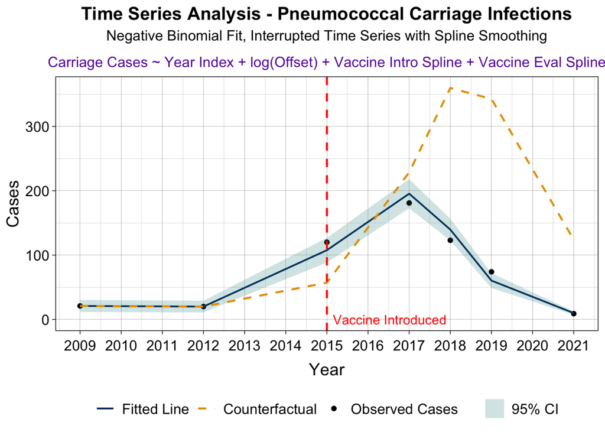

```r
time_series_plot <-
  ggplot(time_series_df.pred.spl, aes(x = Year, y = CCount)) +
      geom_point(aes(color = "Observed Cases")) +
      # adding the fitted line
      geom_line(data = time_series_df.pred.spl, aes(x = Year, y = pred.spl, group = 1, color = "Fitted Line"), size = .7) +
      # adding the confidence interval
      geom_ribbon(data = time_series_df.pred.spl, aes(ymin = conf.low, ymax = conf.high, fill = "95% CI"),
                  alpha = 0.2, group = 1) +
      # adding the counterfactual line
      geom_line(data = time_series_df.pred.spl, aes(x = Year, y = pred.spl.cf, color = "Counterfactual"),
                lty = 2, group = 1, size = .8)  +
  labs(title = "Time Series Analysis - Pneumococcal Carriage Infections",
      subtitle = paste0(
    "<span style='font-size:12pt'>Negative Binomial Fit, Interrupted Time Series with Spline Smoothing</span><br>",
    "<span style='font-size:1pt; color:white'>&nbsp;</span><br>",
    "<span style='font-size:12pt; color:#6A0DAD'>Carriage Cases ~ Year Index + log(Offset) + Vaccine Intro Spline + Vaccine Eval Spline</span>"
  ), x = "Year", y = "Cases"
  ) +
      theme_linedraw() +
  # Adding a vertical line in 2015 to represent vaccine introduction
  geom_vline(xintercept = 2015, color = "red", linetype = "dashed", size = .8) +
  # Creating a legend
    scale_color_manual(name='Legend',
                     breaks=c('Fitted Line', 'Counterfactual', "Observed Cases"),
                     values=c("Fitted Line" = "#00356B","Counterfactual" = "#E69F00", "Observed Cases" = "black")) +
  scale_fill_manual(name='Legend',
                     breaks=c('95% CI'),
                     values=c("95% CI" = "#008080")) +
      # formatting
      theme(panel.spacing = unit(2, 'lines'),
            axis.text.x = element_text(angle = 0, size = 12, vjust = 3, margin = margin(t = 10)),
            axis.text.y = element_text(size = 12),
            axis.title = element_text(size = 12),
            axis.title.x = element_text(size = 14),
            axis.title.y =element_text(size = 14),
            plot.title = element_text(size = 15, face = "bold", hjust = 0.5),
            legend.position = "bottom",
            plot.subtitle = element_markdown(size = 12, hjust = 0.5),
        legend.title = element_blank(),
        legend.text = element_text(size = 12)) +
    scale_x_continuous(
    breaks = seq(
      floor(min(time_series_df.pred.spl$Year, na.rm = TRUE)),
      ceiling(max(time_series_df.pred.spl$Year, na.rm = TRUE)),
      by = 1
    )) +
  # adding annotation on the chart to label the vaccine introduction line
  annotate("text", x = 2015.15, y = 00.1, label = "Vaccine Introduced", color = "red", hjust = 0)
time_series_plot
```

```r
ggsave(filename="Time_Series.jpeg", plot=time_series_plot, width=8, height=5)
```

We next plot the rate ratio over time to analyze the model’s sensitivity:

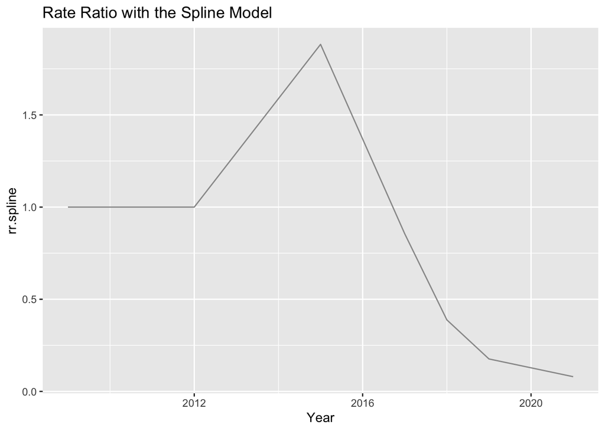

```r
p_ratio <- ggplot() +
     geom_line(data = time_series_df.pred.spl, aes(x = Year, y = rr.spline), group = 1,
               color = "#999999") +
      labs(title = "Rate Ratio with the Spline Model")
p_ratio
```

```r
# Creating a Boolean variable that defines the vaccine evaluation period
eval.period <- time_series_df$Year > 2015

# Calculating the average outcome during the vaccine evaluation period
rr.spline.eval <- mean(time_series_df.pred.spl$rr.spline[eval.period])

# Showing the average decline detected from 1
round(c("ITS - Spline" = rr.spline.eval), digits = 2)
```

```
## ITS - Spline
##         0.37
```

```r
# Showing the percent decline detected
100*(1 - round(c("ITS - Spline" = rr.spline.eval), digits = 2))
```

```
## ITS - Spline
##           63
```

The spline method identified a decrease of approximately 63% in pneumococcal carriage cases due to pneumococcal disease after the release of the PCV10 vaccine.

Equation: carriage cases ~ year index + log(offset) + vaccine intro spline + vaccine evaluation spline